# Midterm Project

Author

Shubhu Shahade

Published

October 4, 2023

## A. Analyzing trends in San Jose rental prices

```r
# LOAD ANY RELEVANT PACKAGES HERE
#install.packages("readr")
#install.packages("curl")
library(ggplot2)
library(dplyr)
rent <- readr::read_csv('https://raw.githubusercontent.com/rfordatascience/tidytuesday/master/data/2022/2022-07-05/rent.csv')
rent
```

```
# A tibble: 200,796 × 17
   post_id     date  year nhood city  county price  beds baths  sqft room_in_apt
   <chr>      <dbl> <dbl> <chr> <chr> <chr>  <dbl> <dbl> <dbl> <dbl>       <dbl>
 1 pre2013_… 2.01e7  2005 alam… alam… alame…  1250     2     2    NA           0
 2 pre2013_… 2.01e7  2005 alam… alam… alame…  1295     2    NA    NA           0
 3 pre2013_… 2.00e7  2004 alam… alam… alame…  1100     2    NA    NA           0
 4 pre2013_… 2.01e7  2012 alam… alam… alame…  1425     1    NA   735           0
 5 pre2013_… 2.00e7  2004 alam… alam… alame…   890     1    NA    NA           0
 6 pre2013_… 2.01e7  2006 alam… alam… alame…   825     1    NA    NA           0
 7 pre2013_… 2.01e7  2007 alam… alam… alame…  1500     1     1    NA           0
 8 63790969… 2.02e7  2017 alam… alam… alame…  2925     3    NA    NA           0
 9 pre2013_… 2.01e7  2009 alam… alam… alame…   450    NA     1    NA           0
10 pre2013_… 2.01e7  2006 alam… alam… alame…  1395     2    NA    NA           0
# ℹ 200,786 more rows
# ℹ 6 more variables: address <chr>, lat <dbl>, lon <dbl>, title <chr>,
#   descr <chr>, details <chr>
```

1. How many 1 bedroom listings from Santa Clara county are in this dataset?

```r
sc_county_1bed <- subset(rent,county == "santa clara" & beds == 1)
print(nrow(sc_county_1bed))
```

```
[1] 12455
```

Santa Clara county has 12455 1 bedroom listings.

2. What is the median price for a 1 bedroom listing in Santa Clara county in 2018?

```r
#rent <- readr::read_csv('https://raw.githubusercontent.com/rfordatascience/tidytuesday/master/data/2022/2022-07-05/rent.csv')
sc_county_1bed_2018 <- subset(sc_county_1bed, year == 2018)
median_value_sc_county_1bed_2018 <- median(sc_county_1bed_2018$price)
print(median_value_sc_county_1bed_2018)
```

```
[1] 2095
```

The median value for 1 bedroom listings in Santa Clara county in 2018 was $2095.

3. Which county has the highest median price for a 1 bedroom listing in 2018?

```r
one_bed_2018 <- subset(rent, beds == 1 & year == 2018)
highest_median_2018_county <- aggregate(one_bed_2018$price, list(one_bed_2018$county), FUN=median, na.rm = TRUE)
print(highest_median_2018_county$Group.1[highest_median_2018_county$x == max(highest_median_2018_county$x)])
```

```
[1] "san francisco"
```

San Francisco county had the highest median price for a 1 bedroom listing in 2018

4. Create two histograms for the prices of 1 bedroom listings in Santa Clara county in 2005 and 2018. Compare and discuss.

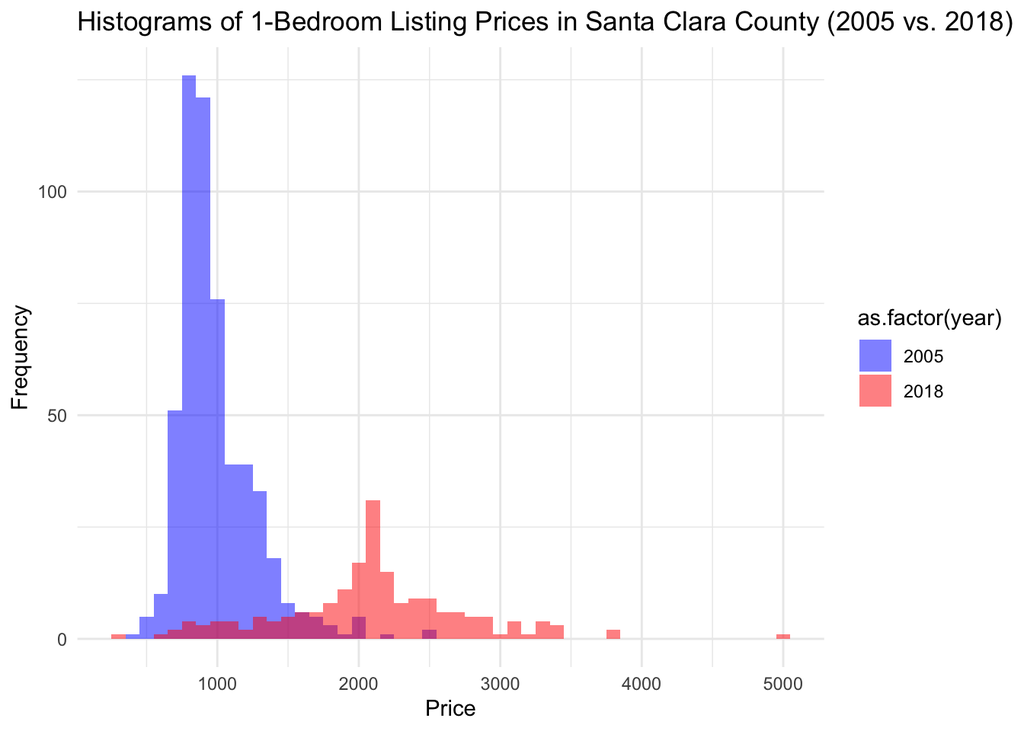

```r
filtered_data <- sc_county_1bed %>%
  filter(year %in% c(2005, 2018))

# Create separate histograms for 2005 and 2018
ggplot(filtered_data, aes(x = price, fill = as.factor(year))) +
  geom_histogram(binwidth = 100, position = "identity", alpha = 0.5) +
  labs(x = "Price", y = "Frequency") +
  ggtitle("Histograms of 1-Bedroom Listing Prices in Santa Clara County (2005 vs. 2018)") +
  scale_fill_manual(values = c("2005" = "blue", "2018" = "red")) +
  theme_minimal()
```

The number of listings for 1 bedroom in Santa Clara County were much higher and the prices were much lower when we compare the year 2005 with 2018. The changes in prices could be a reflection of rising prices overtime.

5. Create and interpret a line plot with year on the x-axis and median price for a 1 bedroom apartment for Santa Clara county on the y-axis from 2000 to 2018.

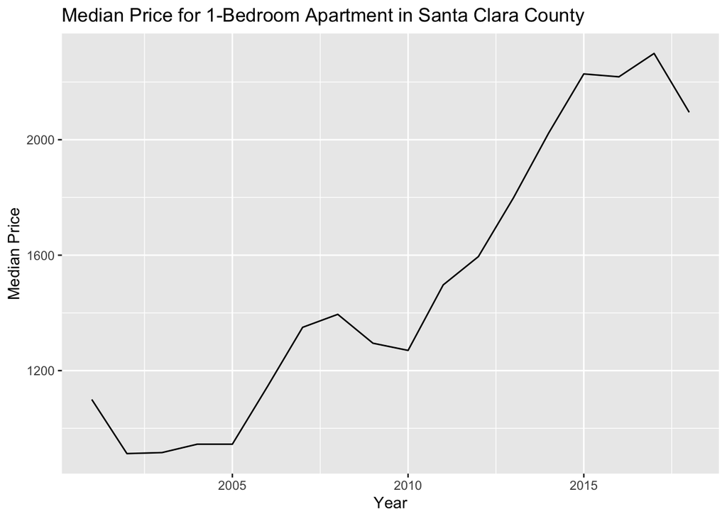

```r
one_bed_sc_county_overtime <- sc_county_1bed %>%
  filter(year >= 2000 & year <= 2018)

median_prices_sc_county <- one_bed_sc_county_overtime %>%
  group_by(year) %>%
  summarise(median_price = median(price))

ggplot(median_prices_sc_county, aes(x = year, y = median_price)) +
  geom_line() +
  labs(x = "Year", y = "Median Price") +
  ggtitle("Median Price for 1-Bedroom Apartment in Santa Clara County")
```

From the lineplot, we can see that the median price for 1 bedroom listing in Santa Clara county has steadily rose till 2017 and then started declining. It was relatively stable during the periods between 2007- 2010 but then followed a sharp upward trend.

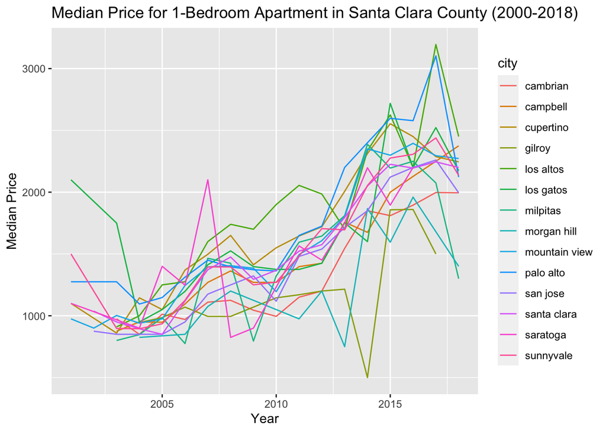

```r
median_prices_by_city_sc <- one_bed_sc_county_overtime %>%
  group_by(year, city) %>%
  summarise(median_price = median(price))
ggplot(median_prices_by_city_sc, aes(x = year, y = median_price, color = city)) +
  geom_line() +
  labs(x = "Year", y = "Median Price") +
  ggtitle("Median Price for 1-Bedroom Apartment in Santa Clara County (2000-2018)")
```

## B. Open ended data visualization

1. What is the relationship between rental prices and number of bedrooms for different cities in Santa Clara county?

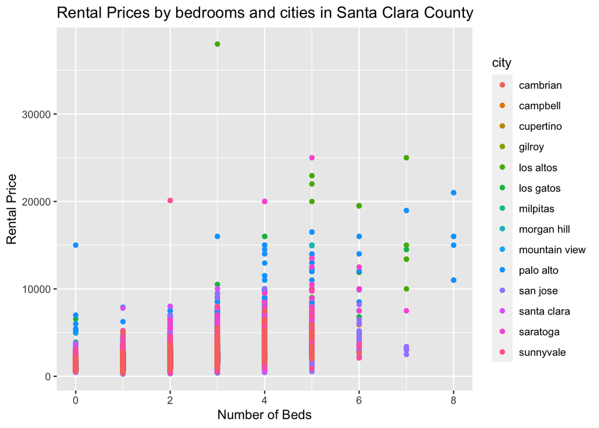

```r
santa_clara_data <- rent %>%
  filter(county == "santa clara")

ggplot(santa_clara_data, aes(x = beds, y = price, color = city)) +
  geom_point() +
  labs(x = "Number of Beds", y = "Rental Price") +
  ggtitle("Rental Prices by bedrooms and cities in Santa Clara County")
```

From the plot we can see that rental prices are relatively higher in some cities like Palo Alto, Los Altos, Los Gatos and a few places in Saratoga. Cities like Cambrian, Cupertino, San Jose and Santa Clara have tons of listings for relatively lower prices varying from 0 bedrooms to 6 bedrooms. There’s only a few listings with 6 or more bedrooms and they’re majorly from San Jose, Los Altos and Palo Alto.

2. How would you compare the relationship between median price and median square feet of the rental listings by each county?

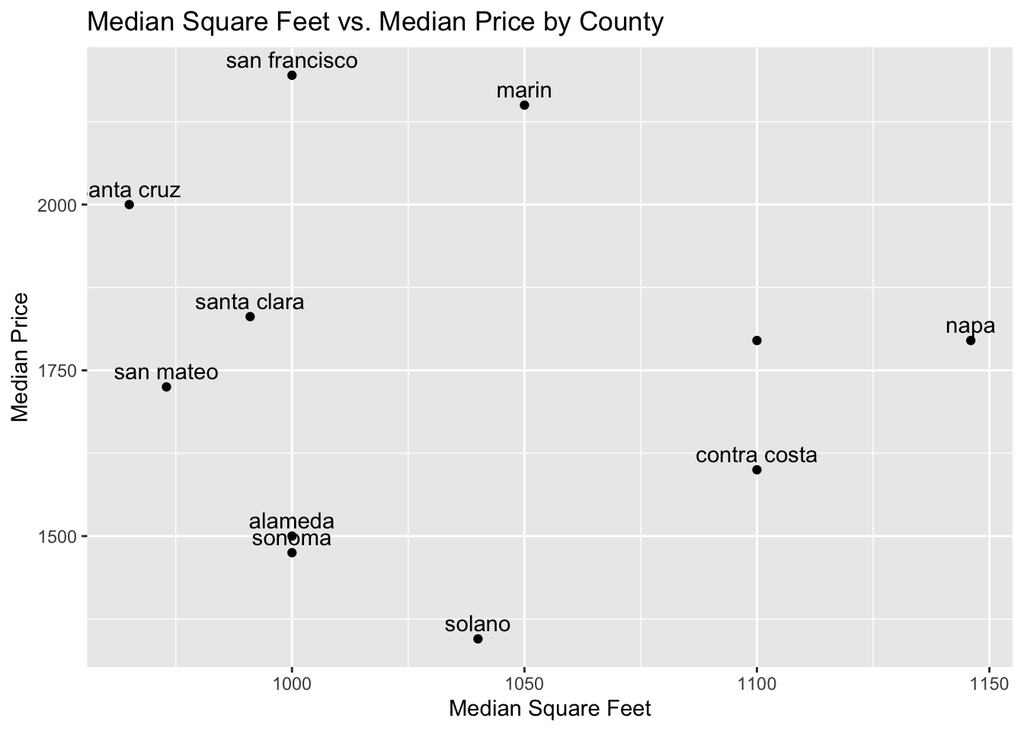

```r
# Calculate median square footage and median price by county
median_data <- rent %>%
  group_by(county) %>%
  summarise(median_sqft = median(sqft, na.rm = TRUE),
            median_price = median(price, na.rm = TRUE))

# Create a scatterplot of median square footage vs. median price by county
ggplot(median_data, aes(x = median_sqft, y = median_price, label = county)) +
  geom_point() +
  geom_text(hjust = 0.5, vjust = -0.5) +
  labs(x = "Median Square Feet", y = "Median Price") +
  ggtitle("Median Square Feet vs. Median Price by County")
```

3. How would you describe the number of rental listings for different counties over the years?

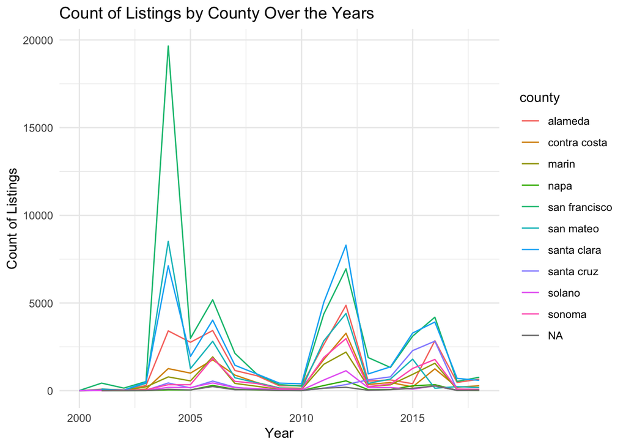

```r
# Group the data by 'county' and 'year' and count the number of listings
listing_counts <- rent %>%
  group_by(county, year) %>%
  summarise(count = n())
# Create a line plot of the count of listings over the years by county
ggplot(listing_counts, aes(x = year, y = count, color = county)) +
  geom_line() +
  labs(x = "Year", y = "Count of Listings") +
  ggtitle("Count of Listings by County Over the Years") +
  theme_minimal()
```